# Using `ergm.sign` to analyse the signed Read’s Highland Tribes dataset

Marc Schalberger

[output not shown]

[output not shown]

[output not shown]

[output not shown]

```r
library(ergm.sign)
```

# Obtaining data

The highland tribes dataset from Read (1954) is included in the `ergm.sign` package:

```r
data("tribes")
```

This gives us a multilayer network construct with a positive and a negative layer encoding the allied and hostile relationships between the tribes.

# Desctiptive statistics

The summary `summary` function returns a matrix with the most important descriptive statistics for the signed network:

```r
summary(tribes)
```

```
## Network Attributes:
```

```
##       Directed Loops Nodes Edges Edges+ Edges- Triads +++ --- ++- +-- Density
## edges    FALSE FALSE    16    58     29     29     68  19   7   2  40    0.48
```

If we would like to get other descriptive statistics using the `summary_formula` function:

```r
summary(tribes ~ edges + Pos(~ edges) + Neg(~ edges))
```

```
##     edges Pos~edges Neg~edges
##        58        29        29
```

# Plotting the network

It is also possible to plot the signed network using the `plot` function. Which requires the `UnLayer` function that turns the multilayer network into a single layer network:

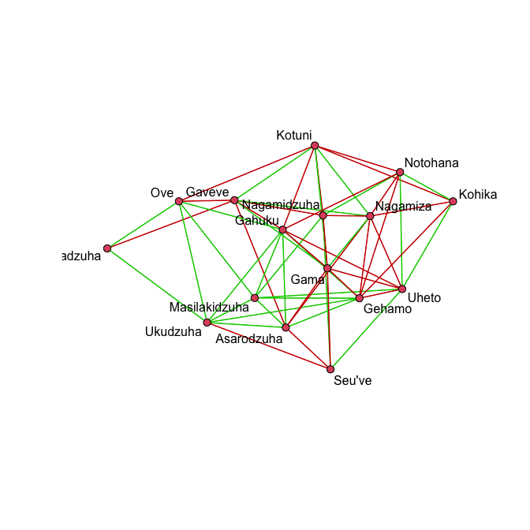

```r
tribes_sgl <- UnLayer(tribes, color_pos = "green3", color_neg = "red3")
plot(tribes_sgl, edge.col = "col", label = "vertex.names")
```

# Fitting a model

Just like in the unsigned case, we can call the `ergm` function to fit a model to the signed network. The `ergm` function requires a formula that specifies the model to be fitted. In addition to the normal ergm terms we can also use the `Pos` and the `Neg` function to specify terms that only apply to the positive or negative layer of the network.

```r
fit <- ergm(tribes ~ Pos(~ edges) + Neg(~ edges))
summary(fit)
```

```
## Call:
## ergm(formula = tribes ~ Pos(~edges) + Neg(~edges))
##
## Monte Carlo Maximum Likelihood Results:
##
##           Estimate Std. Error MCMC % z value Pr(>|z|)
## Pos~edges  -0.7683     0.2362      0  -3.253 0.001140 **
## Neg~edges  -0.7385     0.2189      0  -3.374 0.000742 ***
## ---
## Signif. codes:  0 '***' 0.001 '**' 0.01 '*' 0.05 '.' 0.1 ' ' 1
##
##      Null Deviance:   0.00  on 240  degrees of freedom
##  Residual Deviance: -16.76  on 238  degrees of freedom
##
## Note that the null model likelihood and deviance are defined to be 0. This means that all likelihood-based inference (LRT, Analysis of
## Deviance, AIC, BIC, etc.) is only valid between models with the same reference distribution and constraints.
##
## AIC: -12.76  BIC: -5.8  (Smaller is better. MC Std. Err. = 0.3839)
```

Triadic effects are of particular interest in the context of signed networks.

```r
triad_fit <- ergm(tribes ~ gwese(0.5, fixed = TRUE, base = "+") + gwesf(0.5, fixed = TRUE, base = "+"))
summary(triad_fit)
```

```
## Call:
## ergm(formula = tribes ~ gwese(0.5, fixed = TRUE, base = "+") +
##     gwesf(0.5, fixed = TRUE, base = "+"))
##
## Monte Carlo Maximum Likelihood Results:
##
##              Estimate Std. Error MCMC % z value Pr(>|z|)
## gwese(+).0.5 -0.36000    0.15074      0  -2.388   0.0169 *
## gwesf(+).0.5 -0.04059    0.07468      0  -0.543   0.5868
## ---
## Signif. codes:  0 '***' 0.001 '**' 0.01 '*' 0.05 '.' 0.1 ' ' 1
##
##      Null Deviance:  0.000  on 240  degrees of freedom
##  Residual Deviance: -5.752  on 238  degrees of freedom
##
## Note that the null model likelihood and deviance are defined to be 0. This means that all likelihood-based inference (LRT, Analysis of
## Deviance, AIC, BIC, etc.) is only valid between models with the same reference distribution and constraints.
##
## AIC: -1.752  BIC: 5.209  (Smaller is better. MC Std. Err. = 0.298)
```

Here, the `gwese` (geometrically weighted edgewise shared enemies) term models enemy of my enemy is my friend configuration and the `gwesf` (geometrically weighted edgewise shared friends) term models friend of a friend is a friend configuration.

# Goodness of fit

In order to assess the goodness of fit of the model we can use the `GoF` function, which compares the observed network statistics to the statistics of simulated networks. The `nsim` argument specifies the number of simulations to be performed. For example, to perform 20 simulations we can use the following code:

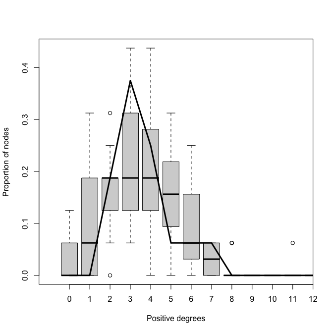

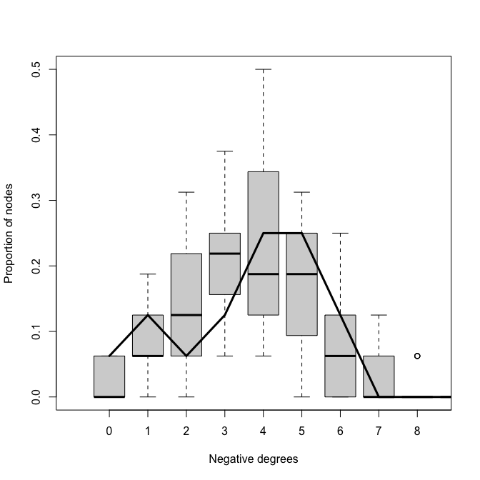

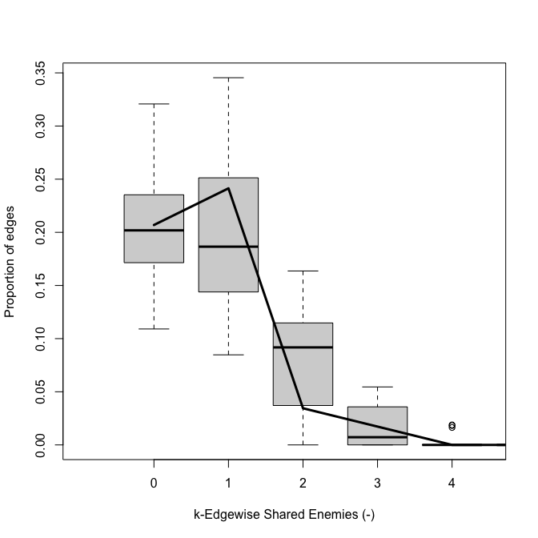

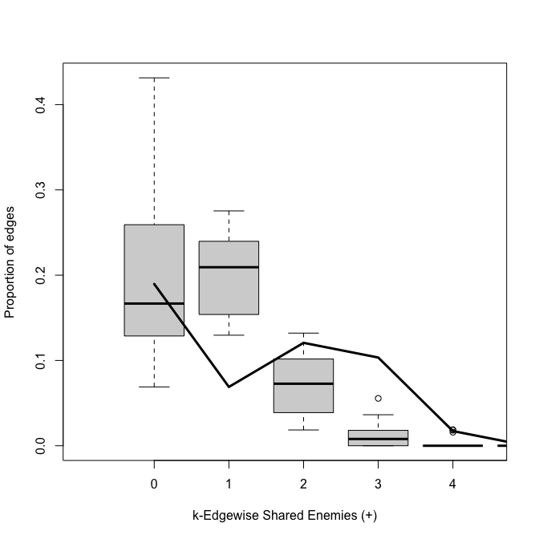

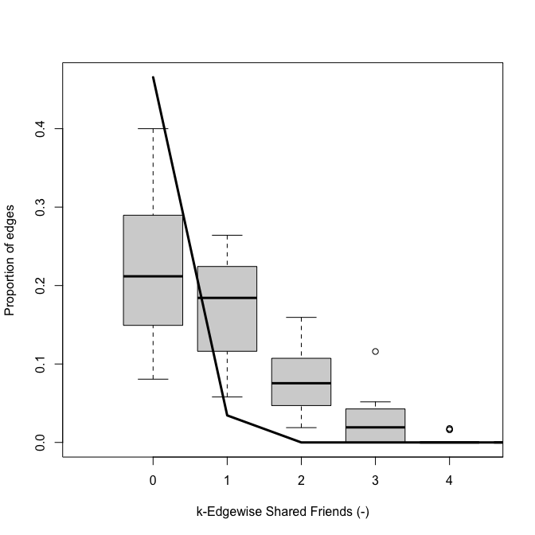

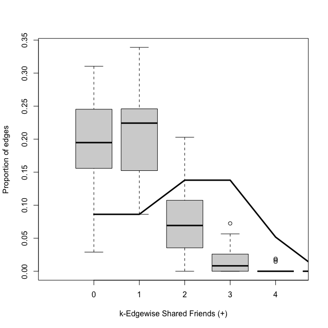

```r
GoF(fit, nsim = 20)
```

# References

Read, Kenneth E. 1954. “Cultures of the Central Highlands, New Guinea.” *Southwestern Journal of Anthropology* 10 (1): 1–43.